# Geometries

Data Visualization - Part 4

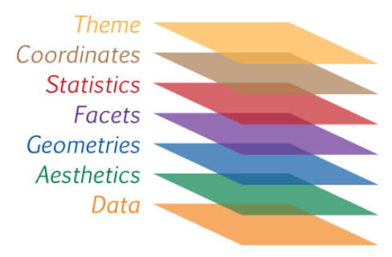

How are these two plots similar?

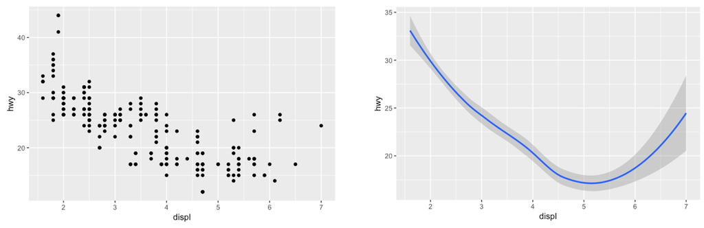

Both plots contain the same x variable, the same y variable, and both describe the same data. But the plots are not identical. Each plot uses a different visual object to represent the data. In ggplot2 syntax, we say that they use different **geoms**.

A **geom** is the geometrical object that a plot uses to represent data. People often describe plots by the type of geom that the plot uses. For example, bar charts use bar geoms, line charts use line geoms, boxplots use boxplot geoms, and so on. Scatterplots break the trend; they use the point geom. The plot on the left uses the point geom, and the plot on the right uses the smooth geom, a smooth line fitted to the data. To change the geom in your plot, change the geom function that you add to `ggplot()`. For instance, to make the plots above, you can use this code:

Left

> `ggplot(data = mpg) + geom_point(mapping = aes(x = displ, y = hwy))`

Right

> `ggplot(data = mpg) + geom_smooth(mapping = aes(x = displ, y = hwy))`

Now we can output both of these layers on top of each other:

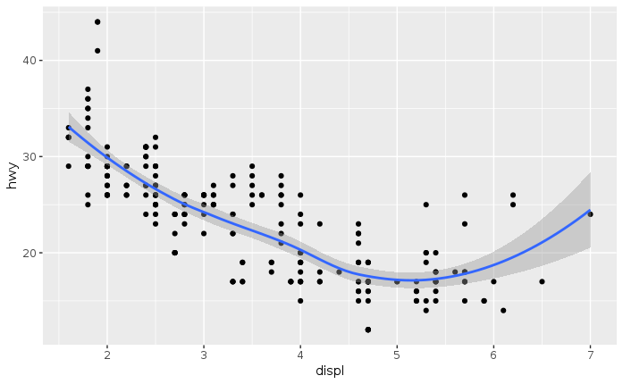

```r
ggplot(data = mpg) +
  geom_point(mapping = aes(x = displ, y = hwy)) +
  geom_smooth(mapping = aes(x = displ, y = hwy))
```

If you look at the help page for `geom_smooth()` you will see `method = "auto"` as a default. `method` is the smoothing method, since the default is on `"auto"` it picked `loess` (LOcal regrESSion), we can change it to linear regression, for instance, by `method = "glm"`:

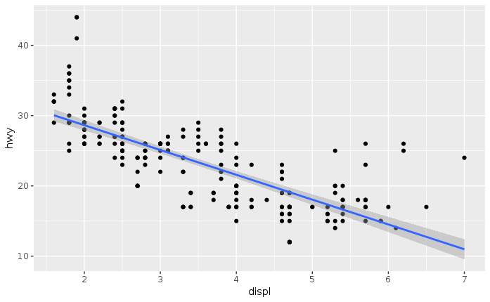

```r
ggplot(data = mpg) +
  geom_point(mapping = aes(x = displ, y = hwy)) +
  geom_smooth(mapping = aes(x = displ, y = hwy), method = "glm")
```

Every geom function in ggplot2 takes a `mapping` argument. However, not every aesthetic works with every geom.

A few examples:

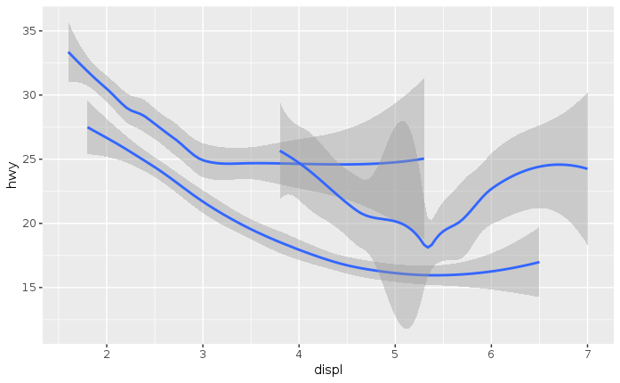

```r
ggplot(data = mpg) +
  geom_smooth(mapping = aes(x = displ, y = hwy, group = drv))
```

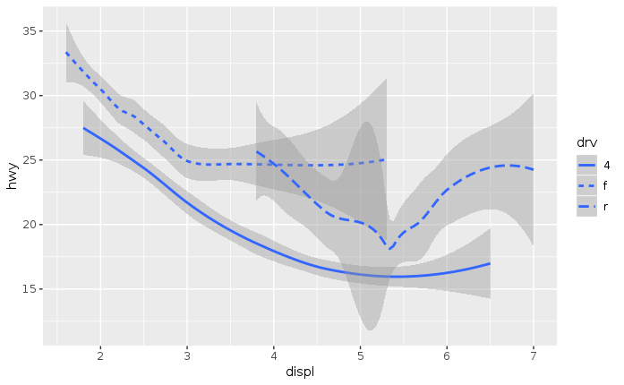

```r
ggplot(data = mpg) +
  geom_smooth(mapping = aes(x = displ, y = hwy, linetype = drv))
```

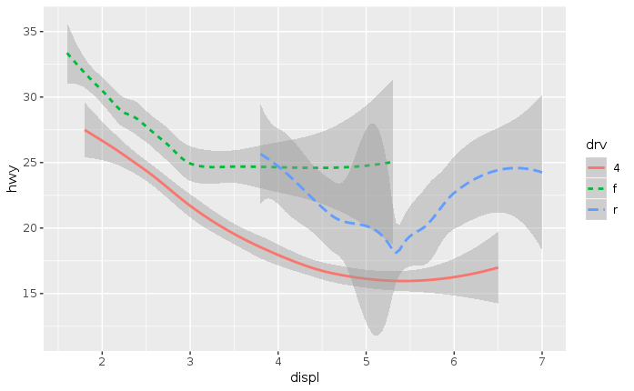

```r
ggplot(data = mpg) +
  geom_smooth(
    mapping = aes(x = displ, y = hwy, color = drv, linetype = drv)
  )
```